# JHDS Capstone-Milestone Report

02/11/2016

## SwiftKey NLP Project Introduction

This report summarizes the first stage of my Capstone project in the Johns Hopkins Data Science specialization. The Capstone focuses on the data science of natural language processing ("NLP"), leveraging the entire course's methodologies and learnings to disect the SwiftKey text dataset. SwiftKey is a corporate partner of Johns Hopkins and Coursera, providing customers with mobile applications and technologies, one of which includes a feature that predicts type-ahead for mobile texters.

The high-level challenge of the Capstone is to create a practical and reliable word prediction application in Shiny, based on a cleaned dataset of text and associated NLP model. The source text is a combination of large volumes of blogs, news articles, and Twitter posts (tweets).

The first stage of the work is to explore, cleanse, and tokenize the text data (break down the sentences and phrases into words and related phrases) in a format that can be later leveraged in a predictive model used by the Shiny application to suggest the "next word" based on one or a series of words entered by a user.

## Data Summary of the SwiftKey Dataset

The source data is downloaded from: https://d396qusza40orc.cloudfront.net/dsscapstone/dataset/Coursera-SwiftKey.zip

The table below is a quick overview of the file size, word count, lines, and maximum sentence length for the blogs, news, and Twitter source data.

|  | source | size.MB | lines | words | max.words |
| --- | --- | --- | --- | --- | --- |
| 1 | blogs | 200.4 | 899288 | 37546246 | 6726 |
| 2 | news | 196.3 | 1010242 | 34762395 | 1796 |
| 3 | twitter | 159.4 | 2360148 | 30093410 | 47 |

The three datasets are very large and would not be efficient enough for real-time prediction within a user application. As a result, I create random samples (binomial distribution), based on 2% each of the news and blogs data and 1% of the Twitter records. The samples targeted approximately 20,000 records in each text dataset.

## Data Cleansing & Important Libraries

Blogs, news, and Twitter posts include a significant amount of data "noise" that prevent quality text analysis. There are foreign words, cryptic abbreviations, extra spaces, unnecessary punctuation and numbers, mixed capitalization, and a variety of other text inconsistencies. For this initial exploration and cleansing, I utilized several text formats, cleansing techniques, and specialty libraries, including:

- **Foreign Language:** Specialty function to remove non-ASCII
- **Twitter:** Used qdapRegex with several function to clean up cryptic Twitter language
- **Corpus:** TM (tm_map) has numerous cleansing functions within a corpus (see below)
- **Profanity:** Ran a function to match-delete against standard profanity text file

Lastly, this exercise would benefit from another 'blacklist filter' beyond profanity, including a direct match against valid English-language dictionary, and also eliminating Twitter text against a library of common abbreviations, such as BFF, LOL, LMAO, etc.

## Word Exploration/Frequency

The next step was to tokenize individual and multi-word combinations/phrases called n-grams. I found 'tidytext' to be a superior and more simple library than the TextDocumentMatrix functions. The 25 most frequently used unigrams (single words) is below:

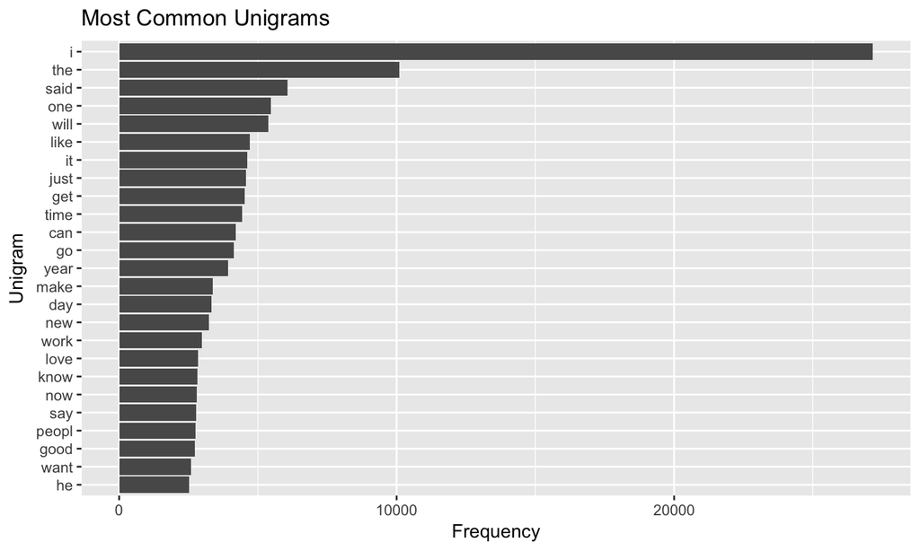

## n-gram Exploration/Frequency

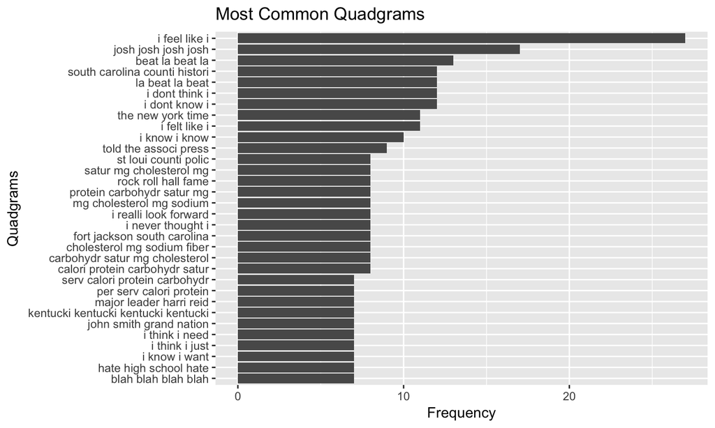

## Word Coverage Analysis

One interesting text data analysis suggested by the assignment asks how many unique English words are 50% of all words across a dataset of blog and news sentences and Twitter posts. How many words provide 90% of all words in the datasets.

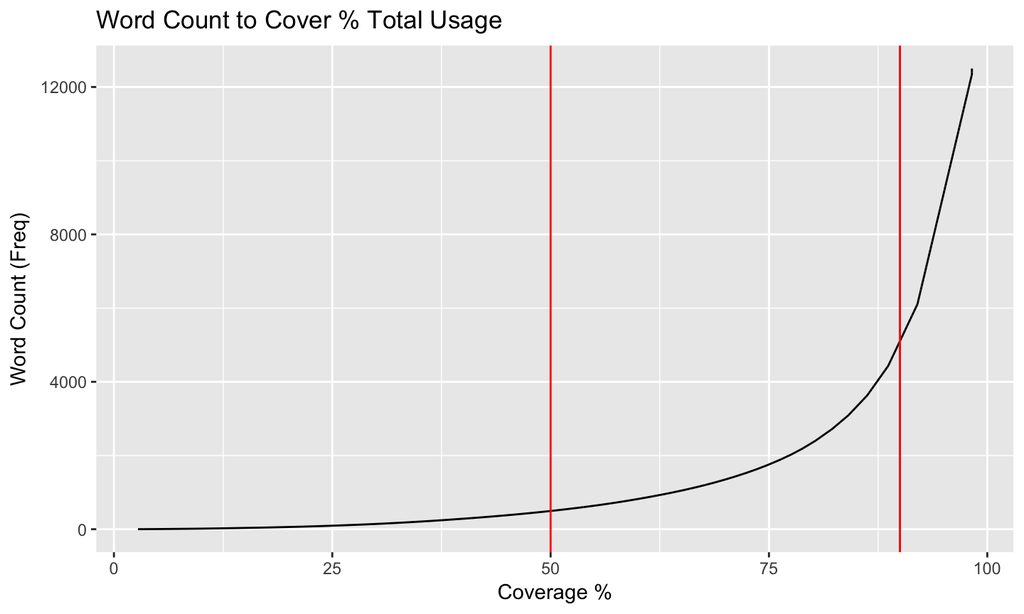